# Project Final Report

Title: AIRBNB Price Prediction-Austin Metro. Area  
Student Id:ubm700  
Course:CS6463  
Index:

1. Research Objective
2. Data Description
   - Data Sources
   - Data Overview
   - Important Fields
1. Data Exploration
   - Data Preparation
   - Feature Engineering
   - Price Analysis
   - Feature Analysis
   - Amenities Cleaning
   - Correlation Matrix
   - Location Analysis
   - Property Analysis
   - Reviews Analysis
   - Amenities Analysis
1. Modeling
   - Modeling Overview
   - Sci-Kit Learn Pipeline
   - Grid Space Search
   - Results
1. Summary
1. References

## Research Objective

The research objective of this project is to first identify the key features and the degree to which they contribute to an AIRBNB's listing price using historical listings data, and then create a empirical pricing prediction model to predict a nightly listing price for a listing in the Austin, TX. metropolitan area.

## Data Description

### Data Sources

#### AIRBNB Dataset

The airbnb dataset is divided into three subsets `listings`, `calendar`, and `reviews` for each geographic area they support. Each subset is available in a monthly timeframe from the AIRBNB website. I downloaded a year's worth of data and extracted, renamed, and reorganized the CSV file into manageable directories.

- Source: AIRBNB
- Source URL: http://insideairbnb.com/get-the-data.html
- City: Austin, Tx
- Data Range: August 2018 - July 2019
- License: Creative Commons CC0 1.0
- Subsets used `listings`

##### Months in study

- 'august*2018*',
- 'september*2018*',
- 'october*2018*',
- 'november*2018*',
- 'december*2018*',
- 'january*2019*',
- 'february*2019*',
- 'march*2019*',
- 'april*2019*',
- 'may*2019*',
- 'june*2019*',
- 'july*2019*'

#### Austin Crime Map

The Austin Crime Map is a CSV record of incidents that the Austin Police Department reported and responded to. It contains information about each incident and and the highest level of offense that occurred.

- **Source**: Austin City Government Open Data Portal
- **Source URL**: https://data.austintexas.gov/Public-Safety/Crime-Reports-2018-Map/fc3e-daxz
- City: Austin, Tx
- Data Range: 01/01/2018 and 12/31/2018
- License: Public Domain

### Data Overview

#### Dataset Shapes

| Dataset | Rows | Columns |
| --- | --- | --- |
| Listings | 150656 | 69 |
| Crime_Map | 101732 | 25 |

### Important Fields

##### AIRBNB Listings Austin

- Listing Location Attributes
- Listing Rent Attributes
- Listing Property Attributes
- Listing Review Attributes

| idx | Columns | Count | Null | Dtype |
| --- | --- | --- | --- | --- |
| 0 | zipcode | 150656 | non-null | int64 |
| 1 | property_type | 150656 | non-null | object |
| 2 | room_type | 150656 | non-null | object |
| 3 | accommodates | 150656 | non-null | int64 |
| 4 | bathrooms | 150331 | non-null | float64 |
| 5 | bedrooms | 150594 | non-null | float64 |
| 6 | beds | 150430 | non-null | float64 |
| 7 | bed_type | 150656 | non-null | object |
| 8 | amenities | 150656 | non-null | object |
| 9 | square_feet | 3329 | non-null | float64 |
| 10 | security_deposit | 102987 | non-null | float64 |
| 11 | cleaning_fee | 117575 | non-null | float64 |
| 12 | guests_included | 150656 | non-null | int64 |
| 13 | extra_people | 150656 | non-null | float64 |
| 14 | minimum_nights | 150656 | non-null | int64 |
| 15 | maximum_nights | 150656 | non-null | int64 |
| 16 | number_of_reviews | 150656 | non-null | int64 |
| 17 | review_scores_rating | 113181 | non-null | float64 |
| 18 | review_scores_accuracy | 113115 | non-null | float64 |
| 19 | review_scores_cleanliness | 113119 | non-null | float64 |
| 20 | review_scores_checkin | 113086 | non-null | float64 |
| 21 | review_scores_communication | 113111 | non-null | float64 |
| 22 | review_scores_location | 112999 | non-null | float64 |
| 23 | review_scores_value | 113007 | non-null | float64 |

#### Austin Crime Map

Zip

| idx | Columns | Count | Null | Dtype |
| --- | --- | --- | --- | --- |
| 0 | Incident_Number | 101732 | non-null | int64 |
| 1 | Highest_Offense_Description | 101732 | non-null | object |
| 2 | Highest_Offense_Code | 101732 | non-null | int64 |
| 3 | Occurred_Date_Time | 101732 | non-null | object |
| 4 | Occurred_Date | 101732 | non-null | object |
| 5 | Occurred_Time | 101732 | non-null | int64 |
| 6 | Report_Date_Time | 101732 | non-null | object |
| 7 | Report_Date | 101732 | non-null | object |
| 8 | Report_Time | 101732 | non-null | int64 |
| 9 | Location_Type | 101135 | non-null | object |
| 10 | Address | 101732 | non-null | object |
| 11 | Zip_Code | 101732 | non-null | float64 |
| 12 | Council_District | 101388 | non-null | float64 |
| 13 | APD_Sector | 101731 | non-null | object |
| 14 | APD_District | 101731 | non-null | object |
| 15 | PRA | 101731 | non-null | float64 |
| 16 | Census_Tract | 55499 | non-null | float64 |
| 17 | Clearance_Status | 92222 | non-null | object |
| 18 | Clearance_Date | 92220 | non-null | object |
| 19 | X-coordinate | 101732 | non-null | float64 |
| 20 | Y-coordinate | 101732 | non-null | float64 |
| 21 | Latitude | 100122 | non-null | float64 |
| 22 | Longitude | 100122 | non-null | float64 |
| 23 | Location | 100122 | non-null | object |
| 24 | zipcode | 101732 | non-null | int64 |

## Data Exploration

### Data Preparation

Before being able to explore the data some cleaning and feature engineering was necessary.

##### Drop Duplicates

Since the listings dataset contains listings from several months aggregated together there are bound to be duplicates. The duplicates were dropped based on the subset of the columns `listing_id`, `price`, and `month`.

A `soft` drop dropped duplicates with `listing_id`, `price`, and `month` matching.

A `hard` drop dropped duplicates with `listing_id`, and `price`

##### Align Datasets by Zipcode

To use the datasets together they were aligned on the common feature `zipcode`. An intersection was made of the `zipcode` columns from each set and records with zipcodes outside the intersection were dropped. This operation results in no loss of data for our main `Listings` DataFrame.

##### New Shapes

| Dataset | Rows | Columns |
| --- | --- | --- |
| Listings | 24859 | 69 |
| Crime_Map | 101726 | 25 |

### Feature Engineering

The set of `zipcodes` contains 51 entries. This makes visualization much harder, so a new feature `region` was created to explore location. The `zipcodes` were divided into the following regions.

##### Regions

| idx | Region | Listings | Zipcodes |
| --- | --- | --- | --- |
| 0 | central | 13149 | 7 |
| 1 | east | 4431 | 13 |
| 2 | north | 3241 | 8 |
| 3 | south | 2023 | 8 |
| 4 | west | 2015 | 15 |

##### Crime Rate

Crime Rate of an area may be a possible feature when determining a listing rent price. To calculate a crime rate per zipcode crime_count was divided by the number of listings in that zipcode. This value was used to create crime_rate by regions as well.

| Region | Listings | Crimes | Crime Rate |
| --- | --- | --- | --- |
| central | 13149 | 22906 | 1.74203 |
| east | 4431 | 39719 | 8.96389 |
| north | 3241 | 23023 | 7.10367 |
| south | 2023 | 13298 | 6.57341 |
| west | 2015 | 2780 | 1.37965 |

### Price Analysis

Since the model will be trying to predict price an investigation into the price distributions is necessary. The statistics show a very high standard deviation and far left field outliers. 95% of all prices are below $1000.00 dollars, but the max is 25 times that.

##### Price Statistics

| Statistic | Value |
| --- | --- |
| count | 24859 |
| mean | 321.222 |
| std | 816.062 |
| min | 0 |
| 25% | 80 |
| 50% | 140 |
| 75% | 273 |
| max | 24999 |

##### Price Boxplot

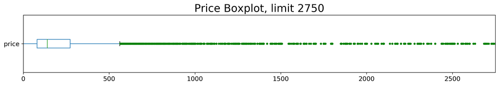

##### Price Distribution

The distribution is not normal. It is skewed to the right and has several peaks beyond the mean. This could be attributed to AIRBNB renters wanting to price rent at intervals of 50 or 100 dollars.

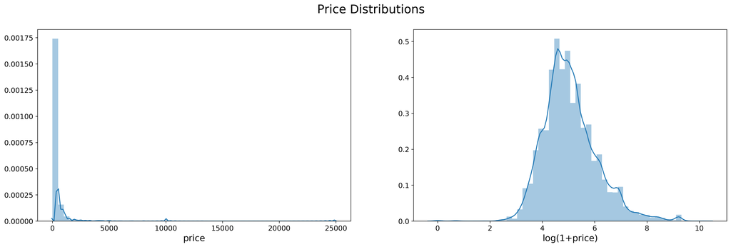

##### Remove Outliers

To remove outliers I used the log(1+x) function. The log values below 3.5 and above 6.5 were removed as outliers. The upper limit was close to the 1.5 x IQR + Q75 value which was $562.00.

##### Statistics

| Statistic | Value |
| --- | --- |
| count | 17577 |
| mean | 176.153 |
| std | 134.177 |
| min | 33 |
| 25% | 80 |
| 50% | 130 |
| 75% | 225 |
| max | 660 |

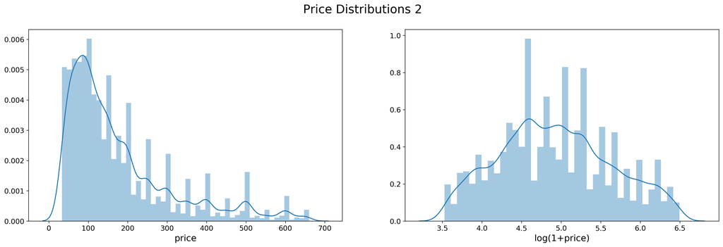

### Feature Analysis

#### Handle Missing Features

After looking at my target `price`, I wanted to see if any missing values remained in my feature list.

- Square_feet missing fields kept too big of a data loss.
- Monetary fields missing values filled with 0
- Review fields missing values either dropped or filled with average based on configuration.
- All other missing fields dropped.

| Column | Missing |
| --- | --- |
| region | 0 |
| crime_rate_zipcode | 0 |
| crime_rate_region | 0 |
| zipcode | 0 |
| property_type | 0 |
| room_type | 0 |
| accommodates | 0 |
| bathrooms | 26 |
| bedrooms | 5 |
| beds | 13 |
| bed_type | 0 |
| amenities | 0 |
| square_feet | 17274 |
| security_deposit | 5014 |
| cleaning_fee | 3223 |
| guests_included | 0 |
| extra_people | 0 |
| minimum_nights | 0 |
| maximum_nights | 0 |
| number_of_reviews | 0 |
| review_scores_rating | 4249 |
| review_scores_accuracy | 4256 |
| review_scores_cleanliness | 4256 |
| review_scores_checkin | 4257 |
| review_scores_communication | 4257 |
| review_scores_location | 4264 |
| review_scores_value | 4264 |

| Dataset | Rows | Columns |
| --- | --- | --- |
| Listings | 17542 | 72 |

#### Amenities Cleaning

The listing dataset contains a column called `amenities` in which each record is a set of amenities offered by that listing. To make this feature more usable, the values were expanded and broken out into one hot encodings. The table below shows some of the common amenities by count of the the total 198 `amenities`.

| idx | Amenity | Count |
| --- | --- | --- |
| 0 | Air conditioning | 17258 |
| 1 | Wifi | 16951 |
| 2 | Heating | 16587 |
| 3 | Kitchen | 16495 |
| 4 | Essentials | 16461 |
| 5 | Smoke detector | 16075 |
| 6 | TV | 14811 |
| 7 | Free parking on premises | 14474 |
| ... | ... | ... |
| 193 | Ski-in/Ski-out | 2 |
| 194 | Alfresco bathtub | 1 |
| 195 | Private gym | 1 |
| 196 | Sauna | 1 |
| 197 | Tennis court | 1 |

### Correlation Matrix

To understand how some of the numeric features relate to each other and especially to price a correlation matrix was created. Three major correlation squares are visible property attributes, reviews, and crime. The list below contains the features that shows a correlation with price.

- Price Correlations
  - Accommodates
  - Bathrooms
  - Bedrooms
  - Beds
  - Square_feet
  - Security Deposit
  - Cleaning Fee
  - Guests Included
  - Extra People

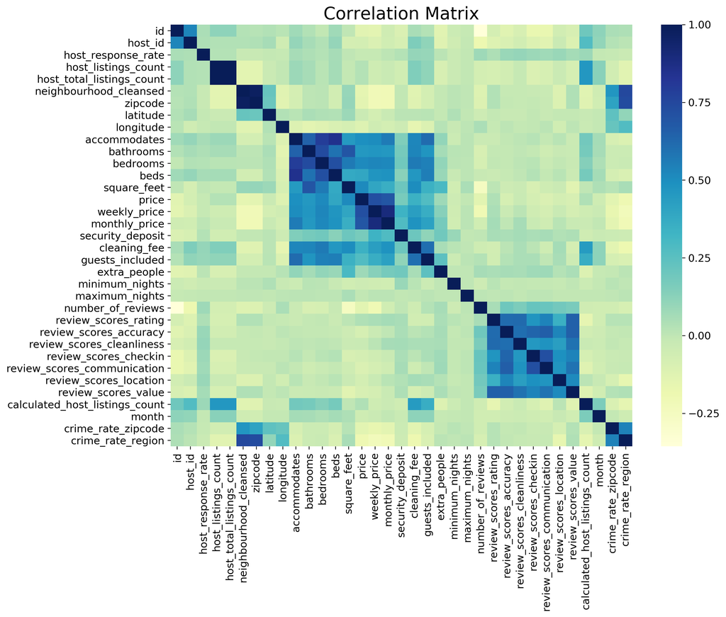

### Location Analysis

A big set of listing features are related to it's location such as `zipcode`, `region`, `latitude`, and `longitude`. Here we analyze some of these features in detail. Region East has the highest crime per listing and has the cheapest average listings. Region West has the lowest crime per listing and has the most expensive average listings. Region Central is the densest region as it contains downtown Austin.

##### Crime and Region

| region | listings | crimes | crime_rate |
| --- | --- | --- | --- |
| central | 13149 | 22906 | 1.74 |
| east | 4431 | 39719 | 8.96 |
| north | 3241 | 23023 | 7.1 |
| south | 2023 | 13298 | 6.57 |
| west | 2015 | 2780 | 1.38 |

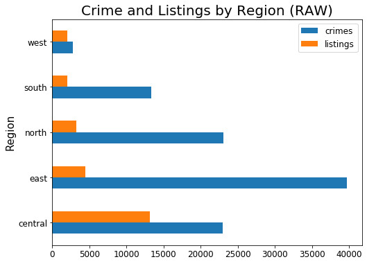

##### Latitude, Logitude Map

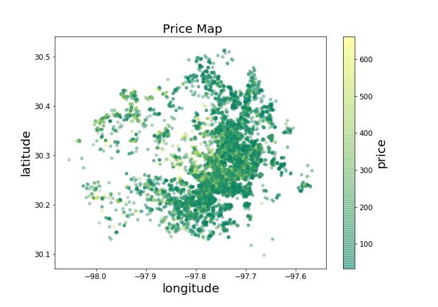

##### Price by Region

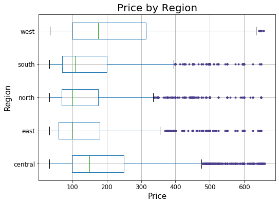

### Property Analysis

In this section we analyze features related to the listing property. The majority of the listings are either houses, apartments, or condominiums. However some people are renting out unusual properties such as boats, buses, and barns. There is a clear direct relationship between accommodates, the number of bedrooms, and the number of bathrooms to the average listing price.

##### Property Types by Region

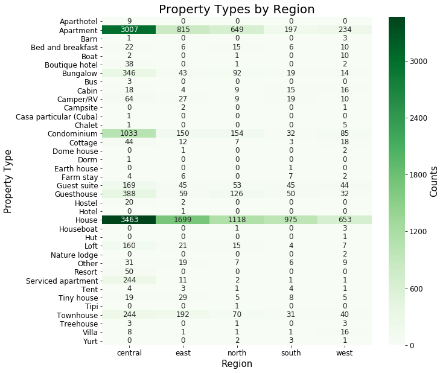

##### Room Type, Accommodates, and Price

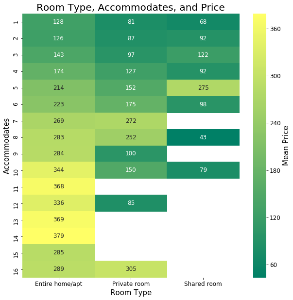

##### Bedrooms, Regions, and Price

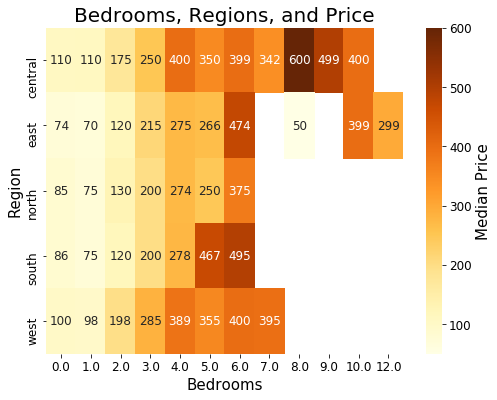

##### Bedrooms, Beds, and Price

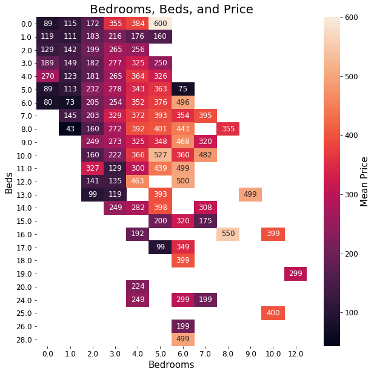

##### Bedrooms, Bathroom, and Price

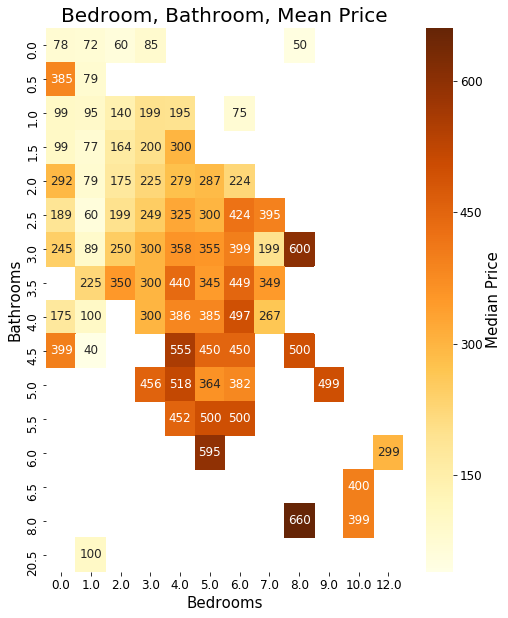

### Reviews Analysis

In this section reviews are analyzed. Each review is a an integer value. The rating score is the overall score for a listing and is between 0 and 100. The remaining 6 scores, accuracy, cleanliness, check-in, communication, location, and value are set between 1 and 10. There does not seem to be a very strong relationship between reviews and price. As long as the reviews are not terribly negative the listing is not impact by the review factor.

##### Overall Ratings, Regions, and Price

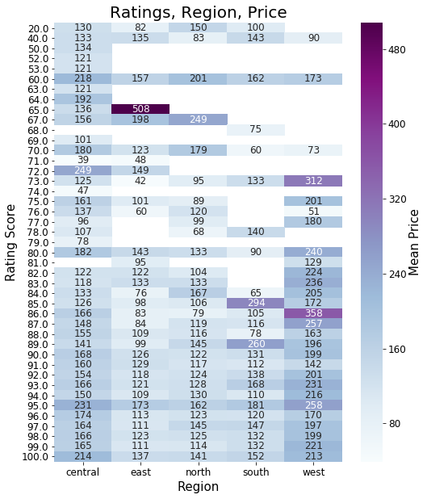

##### Accuracy Ratings, Regions, and Price

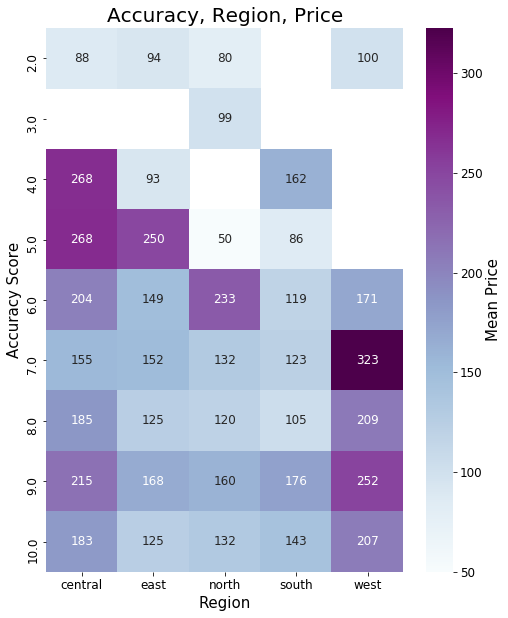

##### Cleanliness Ratings, Regions, and Price

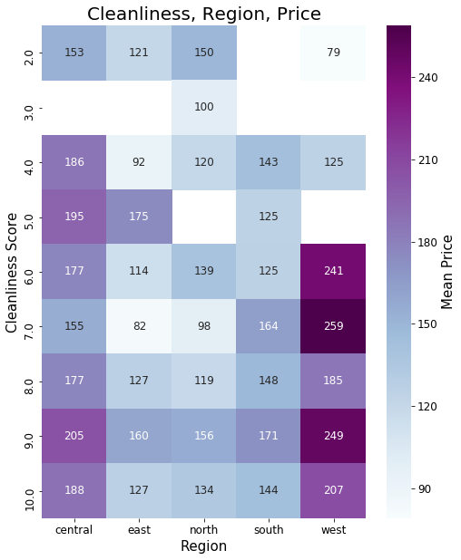

##### Check-In Ratings, Regions, and Price

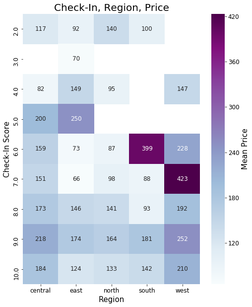

##### Communication Ratings, Regions, and Price

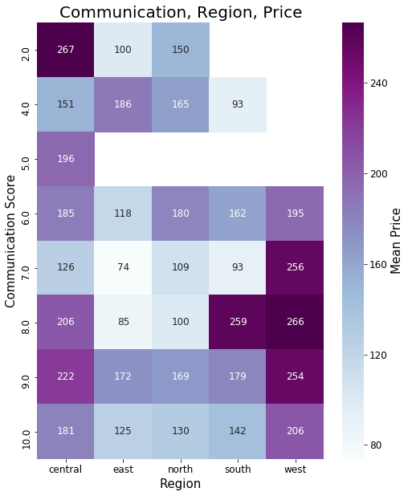

##### Location Ratings, Regions, and Price

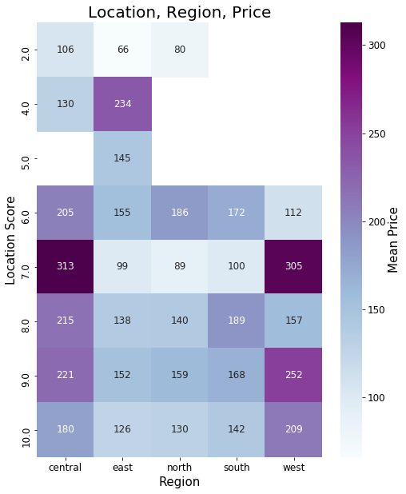

##### Value Ratings, Regions, and Price

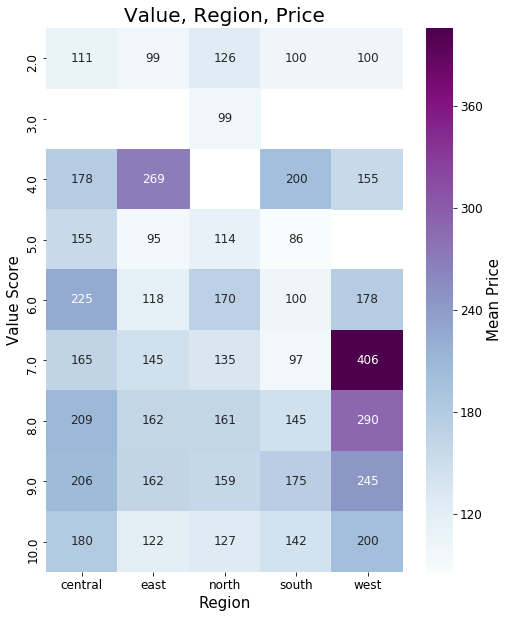

### Amenities Analysis

In this section the special feature `amenities` are analyzed. The presence of these specific amenities may affect the rent price of a listing. All amenities were one hot encoded to build models with but unfortunately did not emerge as a top feature. This may be due to the majority of the listings supporting basic amenities such as air conditioning, heating, wifi, and TV. The uniquer amenities did not impact price enough as an aggregate to become useful.

##### Top 15 Amenities

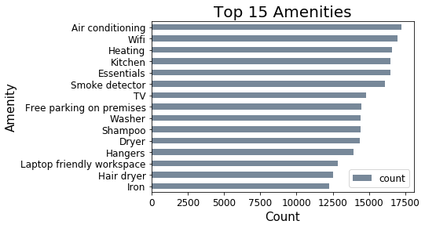

## Modeling

### Modeling Overview

##### Features

| idx | Columns |
| --- | --- |
| 0 | crime_rate_zipcode |
| 1 | crime_rate_region |
| 2 | zipcode |
| 3 | accommodates |
| 4 | bathrooms |
| 5 | bedrooms |
| 6 | beds |
| 7 | security_deposit |
| 8 | cleaning_fee |
| 9 | guests_included |
| 10 | extra_people |
| 11 | minimum_nights |
| 12 | maximum_nights |
| 13 | number_of_reviews |
| 14 | review_scores_rating |
| 15 | review_scores_accuracy |
| 16 | review_scores_cleanliness |
| 17 | review_scores_checkin |
| 18 | review_scores_communication |
| 19 | review_scores_location |
| 20 | review_scores_value |

### Sci-Kit Learn Pipeline

| Model | r2 | RMSE |
| --- | --- | --- |
| SVR | 0.34 | 111.43 |
| Decision Tree Regression | 0.18 | 123.96 |
| Linear Regression | 0.39 | 106.54 |
| KNeighbors Regression | 0.43 | 103 |
| Random Forest Regression | 0.55 | 91.32 |
| XGB Boost Regression | 0.52 | 94.68 |

##### Model Comparison r2

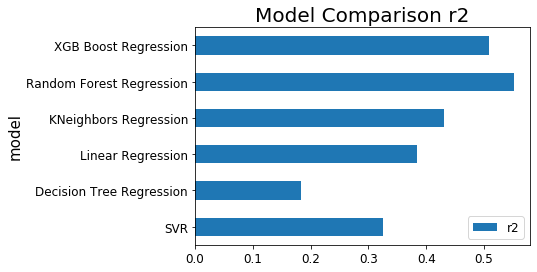

### Parameter Space Search

##### Grid Search CV

```
'n_estimators': [100, 150, 200, 400],
'learning_rate': [0.01, 0.02, 0.3, 0.4],
'max_depth': [3, 4, 5, 6, 7, 10],
'colsample_bytree': [0.6, 0.7, 1],
'gamma': [0.0, 0.1, 0.2, 0.3]
```

##### Best Parameters

```
'colsample_bytree': 0.6,
'gamma': 0.1,
'learning_rate': 0.02,
'max_depth': 10,
'n_estimators': 400
```

##### Time

```
Wall time: 1h 34min 16s
```

### Results after Optimization

##### Final R2 and RMSE Scores

Here I played around with adding and removing `amenities` as a one hot encoded feature. After several trials and runs the following model metrics were the best possible.

| XGB Boost | TRAIN | TEST |
| --- | --- | --- |
| r2 | 0.96 | 0.57 |
| RMSE | 25.48 | 88.98 |

##### Top 10 Frequency

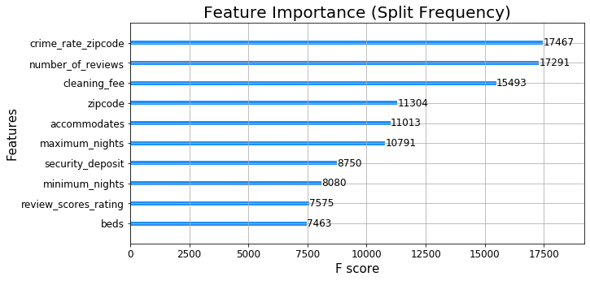

##### Top 10 Weights

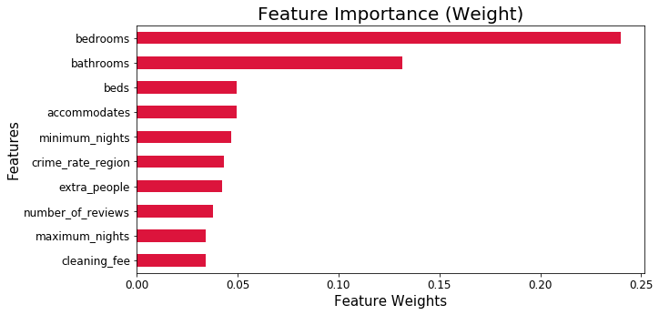

##### Top 20 Features

| idx | Columns | Count |
| --- | --- | --- |
| 0 | bedrooms | 0.253443 |
| 1 | bathrooms | 0.136584 |
| 2 | minimum_nights | 0.048619 |
| 3 | beds | 0.047234 |
| 4 | extra_people | 0.044005 |
| 5 | accommodates | 0.043054 |
| 6 | number_of_reviews | 0.039455 |
| 7 | crime_rate_region | 0.038393 |
| 8 | security_deposit | 0.034862 |
| 9 | maximum_nights | 0.033832 |
| 10 | cleaning_fee | 0.03239 |
| 11 | zipcode | 0.03224 |
| 12 | guests_included | 0.031875 |
| 13 | review_scores_value | 0.028383 |
| 14 | review_scores_checkin | 0.02702 |
| 15 | crime_rate_zipcode | 0.023686 |
| 16 | review_scores_cleanliness | 0.022266 |
| 17 | review_scores_location | 0.021837 |
| 18 | review_scores_rating | 0.020688 |
| 19 | review_scores_accuracy | 0.020111 |

## Summary

In this project I tried to create a nightly AIRBNB listing price prediction model based on the geographic, physical, and monetary aspects of a listing. Out of the models I tried Extreme Gradient Boosted trees performed the best. The RSME value of the trained model was very high at around 88. Since RSME is in the same units as the prediction a +- $88.00 deviation from the predicted price makes the model not very useful for predicting purposes. The r2 value was around 0.57 so 43 percent of variations are unexplained. These I believe are due to the feature set not capturing all aspects of the listing such as photos and host statuses. My research goal of identifying key listing features that contribute to price was somewhat successful, as the model identified accommodates, bedrooms, bathrooms, and zipcode as useful features. Furthermore the dataset was relatively small with an abnormal distribution leading to difficulties in model prediction. However I do think that the same process if applied to a bigger AIRBNB city such as New York or Paris can result in a better predictive model.

## References

1. Austin Police Department. (2018). Crime-Reports-2018-Map [Data set]. City of Austin, Texas Open Data Portal. https://data.austintexas.gov/Public-Safety/Crime-Reports-2018-Map/fc3e-daxz
2. Austin Texas AIRBNB [DataSet]. Listings, Calendar, Reviews, Neighborhoods. [Online]. Available: http://insideairbnb.com/get-the-data.html. [Accessed: 20-Oct-2019].
3. “Austin Zip Code Map - Realty Austin - Search Homes by Zip Code,” Realty Austin. [Online]. Available: https://www.realtyaustin.com/zip-codes.php. [Accessed: 03-Dec-2019].
4. B. bettendorf, “Predicting Prices: XGBoost & Feature Engineering,” Kaggle, 06-Mar-2019. [Online]. Available: https://www.kaggle.com/brittabettendorf/predicting-prices-xgboost-feature-engineering. [Accessed: 03-Dec-2019].
5. D. Cummings, “Austin Zipcodes,” Tableau Public. [Online]. Available: https://public.tableau.com/profile/daniel.cummings#!/vizhome/Airbnb_Austin_TX/MedianRentalPrice. [Accessed: 03-Dec-2019].
6. D. Cummings, “Exploring and predicting Airbnb rental prices in Austin, Texas,” Medium, 17-Dec-2018. [Online]. Available: https://medium.com/@daniel.j.cummings/exploring-and-predicting-airbnb-rental-prices-in-austin-texas-88cfa10258fd. [Accessed: 03-Dec-2019].
1. J. Chen, C.-H. Wu, Y. Zhou, S. D. Mars, F. Yang, and L. Zhang, “Customized Regression Model for Airbnb Dynamic Pricing,”Proceedings of the 24th ACM SIGKDD International Conference on Knowledge Discovery & Data Mining - KDD 18, Aug. 2018.
2. K. abahshetsyan, “Boston Airbnb visualization,” Kaggle, 22-Nov-2016. [Online]. Available: https://www.kaggle.com/kostyabahshetsyan/boston-airbnb-visualization. [Accessed: 03-Dec-2019].
3. R. Chawla, “Analyzing the AirBnB Dataset for trends using Data Visualizations and Modeling,” Medium, 13-Mar-2019. [Online].Available:https://medium.com/ml2vec/data-analysis-on-the-airbnb-dataset-e0be9254eeb9. [Accessed: 22-Sep-2019]
1. T. Plumer, “Exploring the Seattle AirBnB Dataset,” *Medium*,30-Sep-2019. [Online]. Available: https://medium.com/analytics-vidhya/exploring-the-seattle-airbnb-dataset-3cb0df7699d3.[Accessed: 20-Oct-2019].
2. Z. Zhang et al, "Key Factors Affecting the Price of Airbnb Listings: A Geographically Weighted Approach," Sustainability, vol. 9, (9), pp. 1635, 2017.

## Presentation Credit

Do not put anything below this cell.